# Data Wrangling

Retrieve and process the survey’s data.

Hauke Roggenkamp https://github.com/Howquez (CLICCS)https://www.cliccs.uni-hamburg.de/  
2021-05-14

```r
knitr::opts_chunk$set(echo = FALSE)

library(data.table)
library(kableExtra)
library(downloadthis)
library(stringr)
library(magrittr)
library(tidyverse)
library(wesanderson)
library(glue)
library(gridExtra)
```

# Load & subset data

```r
# read data
DT <- read.csv(file="../data/pilot/all_apps_wide_2021-05-14.csv",
               stringsAsFactors = FALSE) %>% data.table()

if(knitr::is_html_output()){
  DT %>%
    download_this(
          output_name = "rawData",
          output_extension = ".csv", # CSV output
          button_label = "Download raw data",
          button_type = "default",
        )
}
```

```r
DT %>%
  head(n = 10) %>%
  kbl() %>%
  scroll_box(width="120%") %>%
  kable_paper("hover",
              full_width = TRUE,
              fixed_thead = TRUE)
```

| participant.id_in_session | participant.code | participant.label | participant._is_bot | participant._index_in_pages | participant._max_page_index | participant._current_app_name | participant._current_page_name | participant.time_started | participant.visited | participant.mturk_worker_id | participant.mturk_assignment_id | participant.payoff | participant.payoff_plus_participation_fee | session.code | session.label | session.mturk_HITId | session.mturk_HITGroupId | session.comment | session.is_demo | session.config.treatment | session.config.participation_fee | session.config.real_world_currency_per_point | session.config.location | Intro.1.player.id_in_group | Intro.1.player.window_width | Intro.1.player.window_height | Intro.1.player.browser | Intro.1.player.wrong_answer_1 | Intro.1.player.wrong_answer_2 | … |
| --- | --- | --- | --- | --- | --- | --- | --- | --- | --- | --- | --- | --- | --- | --- | --- | --- | --- | --- | --- | --- | --- | --- | --- | --- | --- | --- | --- | --- | --- | --- |
| 1 | 17ogiqcy | kmAObgQ0vl | 0 | 20 | 20 | Outro | Results | 2021-05-09 08:31:30.395954+00:00 | 1 | NA | NA | 10 | 15 | ew2r9dqe | NA | NA | NA | NA | 0 | random | 5 | 1 | random | 1 | 1536 | 754 | Chrome 90 | 0 | 0 | … |
| 2 | 3mo3j6tk | Uf7cUAPzho | 0 | 3 | 20 | Uncertainty | Baillon_Decision | 2021-05-09 08:34:21.325839+00:00 | 1 | NA | NA | 0 | 5 | ew2r9dqe | NA | NA | NA | NA | 0 | random | 5 | 1 | random | 2 | 768 | 921 | Safari 14 | 0 | 0 | … |
| 3 | if4h90kt | ounG7HkUFl | 0 | 1 | 20 | Intro | Intro_Welcome | 2021-05-09 08:35:30.329909+00:00 | 1 | NA | NA | 0 | 5 | ew2r9dqe | NA | NA | NA | NA | 0 | random | 5 | 1 | random | 3 | NA | NA |  | 0 | 0 | … |
| 4 | 030qxo6u | 5guVtjLPot | 0 | 20 | 20 | Outro | Results | 2021-05-09 08:36:24.885434+00:00 | 1 | NA | NA | 10 | 15 | ew2r9dqe | NA | NA | NA | NA | 0 | random | 5 | 1 | random | 4 | 1920 | 969 | Chrome 90 | 0 | 0 | … |
| 5 | dlullt0t | NKpHBSeIXG | 0 | 2 | 20 | Intro | Intro_Instructions | 2021-05-09 08:40:45.265947+00:00 | 1 | NA | NA | 0 | 5 | ew2r9dqe | NA | NA | NA | NA | 0 | random | 5 | 1 | random | 5 | 1920 | 950 | Firefox 88 | 3 | 3 | … |
| 6 | gc1zspvl | pgcyLgSRFi | 0 | 20 | 20 | Outro | Results | 2021-05-09 08:41:05.956723+00:00 | 1 | NA | NA | 10 | 15 | ew2r9dqe | NA | NA | NA | NA | 0 | random | 5 | 1 | random | 6 | 414 | 761 | Firefox 85 | 0 | 0 | … |
| 7 | ja4a98ce | meH0n4F8XY | 0 | 20 | 20 | Outro | Results | 2021-05-09 08:44:21.405725+00:00 | 1 | NA | NA | 0 | 5 | ew2r9dqe | NA | NA | NA | NA | 0 | random | 5 | 1 | random | 7 | 1536 | 772 | Firefox 78 | 13 | 5 | … |
| 8 | lu7a97cv | QAwnTEJUvR | 0 | 20 | 20 | Outro | Results | 2021-05-09 08:46:03.147480+00:00 | 1 | NA | NA | 10 | 15 | ew2r9dqe | NA | NA | NA | NA | 0 | random | 5 | 1 | random | 8 | 2560 | 1298 | Chrome 81 | 0 | 0 | … |
| 9 | tps2k35o | kZf10mtoDV | 0 | 20 | 20 | Outro | Results | 2021-05-09 08:50:12.747372+00:00 | 1 | NA | NA | 0 | 5 | ew2r9dqe | NA | NA | NA | NA | 0 | random | 5 | 1 | random | 9 | 598 | 336 | Chrome 4 | 1 | 0 | … |
| 10 | zo64okzh | puffez06wj | 0 | 20 | 20 | Outro | Results | 2021-05-09 08:52:25.404399+00:00 | 1 | NA | NA | 0 | 5 | ew2r9dqe | NA | NA | NA | NA | 0 | random | 5 | 1 | random | 10 | 414 | 715 | Safari 14 | 6 | 3 | … |

Because most of the variables are secondary, I subset the data we are most interested in, that is, the variables needed to identify subjects (IDs) as well as the variables needed to calculate Baillon et al. (2018)’s indices. To conduct analyses with covariates and treatment information, one can use the IDs and merge the data.

```r
# select relevant columns for main- and control variables separately
mainRegex <- "^participant\\.code$|matching_probability$|event_decision$|Comprehension$"
mainVariables <- str_subset(string = names(DT),
                            pattern = mainRegex)
mt <- DT[participant._index_in_pages == 20,# Outro.1.player.Comprehension != "no",
         ..mainVariables] #"mt" for Main Table (in contrast to "Control Table" oder "Data Table")
```

# Rename data

To make the variables a little more readable, I’ll remove the `.player` substring.[^1]

```r
oldNames <- names(mt)
newNames <- str_replace_all(string=oldNames,
                            pattern="\\.player",
                            replacement="")
setnames(x=mt,
         old=oldNames,
         new=newNames)
```

# Prepare indices

This step is not necessary and needs to be adjusted as soon as we become interested in the events itself. But for the time being, I replace the event values to `composite` or `single`. This is fairly simple, because the longer event strings indicate that the subject had to bet on composite events. As a consequence, replace the values is a matter of counting characters.

```r
for(round in 1:12){

  col = glue("Uncertainty.{round}.event_decision")

  set(x = mt,
      i = which(mt[[col]] %>% as.character() %>% nchar() > 2),
      j = col,
      value = "composite")

  set(x = mt,
      i = which(mt[[col]] %>% as.character() %>% nchar() == 2),
      j = col,
      value = "single")
}
```

# Calculate indices

The subjects played the Baillon-tasks twice in the same order of events. Due to laziness, the calculation of the two sets of indices (one pre- and one post-treatment) lacks elegance and is done in two code chunks.[^2] The pre-treatment indices are calculated as follows:

```r
#..calculate Baillons Indices
for(row in 1:NROW(mt)){

  #..first get a vector of event types
  vector = c()
  for(round in 1:6){
    col = glue("Uncertainty.{round}.event_decision")
    vector = append(vector, mt[row, get(col)])
  }

  # consider composite events first and get the round numbers where composite events were shown
  cEvents = str_which(string = vector,
                       pattern = "composite")
  # now loop over these rounds to add the respective matching_probabilities
  CEPs = NULL # Compound-Event Probabilities
  for(compositeRound in cEvents){
    col <- glue("Uncertainty.{compositeRound}.matching_probability")
    increment <- mt[row, get(col)]
    CEPs <- append(CEPs, increment)
  }
  # average
  ACEP = mean(CEPs, na.rm=TRUE)/100

  # do the same for single events
  sEvents <- str_which(string = vector,
                       pattern = "single")
  SEPs = NULL
  for(singleRound in sEvents){
    col <- glue("Uncertainty.{singleRound}.matching_probability")
    increment <- mt[row, get(col)]
    SEPs <- append(SEPs, increment)
  }
  ASEP = mean(SEPs, na.rm=TRUE)/100

  # calculate Ambiguity Aversion Index (AAI)
  AAI = 1 - ACEP - ASEP

  # calculate  ambiguity-generated insensitivity (a-insensitivity) index (AGII)
  AGII = 3 * (1/3 - (ACEP - ASEP))

  # write indices
  mt[row,
     pre_AAI := AAI]
  mt[row,
     pre_AGII := AGII]
}
```

The post-treatment indices’ calculation follows the same rules but adds a `+6` to the event vectors. This is ugly but feasible because the sequence of events in the first 6 rounds is exactly the same as in rounds 7-12.

```r
#..calculate Baillons Indices
for(row in 1:NROW(mt)){

  #..first get a vector of event types
  vector = c()
  for(round in 1:6){
    col = glue("Uncertainty.{round}.event_decision")
    vector = append(vector, mt[row, get(col)])
  }

  # consider composite events first and get the round numbers where composite events were shown
  cEvents = str_which(string = vector,
                       pattern = "composite") + 6
  # now loop over these rounds to add the respective matching_probabilities
  CEPs = NULL # Compound-Event Probabilities
  for(compositeRound in cEvents){
    col <- glue("Uncertainty.{compositeRound}.matching_probability")
    increment <- mt[row, get(col)]
    CEPs <- append(CEPs, increment)
  }
  # average
  ACEP = mean(CEPs, na.rm=TRUE)/100

  # do the same for single events
  sEvents <- str_which(string = vector,
                       pattern = "single") + 6
  SEPs = NULL
  for(singleRound in sEvents){
    col <- glue("Uncertainty.{singleRound}.matching_probability")
    increment <- mt[row, get(col)]
    SEPs <- append(SEPs, increment)
  }
  ASEP = mean(SEPs, na.rm=TRUE)/100

  # calculate Ambiguity Aversion Index (AAI)
  AAI = 1 - ACEP - ASEP

  # calculate  ambiguity-generated insensitivity (a-insensitivity) index (AGII)
  AGII = 3 * (1/3 - (ACEP - ASEP))

  # write indices
  mt[row,
     post_AAI := AAI]
  mt[row,
     post_AGII := AGII]
}
```

Having done that, the data looks as follows.

```r
mt %>%
  head(n = 10) %>%
  kbl() %>%
  scroll_box(width="120%") %>%
  kable_paper("hover",
              full_width = TRUE,
              fixed_thead = TRUE)
```

| participant.code | Uncertainty.1.matching_probability | Uncertainty.1.event_decision | Uncertainty.2.matching_probability | Uncertainty.2.event_decision | Uncertainty.3.matching_probability | Uncertainty.3.event_decision | Uncertainty.4.matching_probability | Uncertainty.4.event_decision | Uncertainty.5.matching_probability | Uncertainty.5.event_decision | Uncertainty.6.matching_probability | Uncertainty.6.event_decision | Uncertainty.7.matching_probability | Uncertainty.7.event_decision | Uncertainty.8.matching_probability | Uncertainty.8.event_decision | Uncertainty.9.matching_probability | Uncertainty.9.event_decision | Uncertainty.10.matching_probability | Uncertainty.10.event_decision | Uncertainty.11.matching_probability | Uncertainty.11.event_decision | Uncertainty.12.matching_probability | Uncertainty.12.event_decision | Outro.1.Comprehension | pre_AAI | pre_AGII | post_AAI | post_AGII |
| --- | --- | --- | --- | --- | --- | --- | --- | --- | --- | --- | --- | --- | --- | --- | --- | --- | --- | --- | --- | --- | --- | --- | --- | --- | --- | --- | --- | --- | --- |
| 17ogiqcy | 25 | single | 60 | composite | 35 | single | 45 | composite | 75 | composite | 55 | single | 79 | single | 97 | composite | 3 | single | 82 | composite | 21 | composite | 18 | single | yes | 0.0166667 | 0.35 | 0.0000000 | 0.00 |
| 030qxo6u | 65 | composite | 50 | composite | 20 | single | 25 | single | 58 | composite | 15 | single | 65 | composite | 50 | composite | 27 | single | 15 | single | 5 | composite | 0 | single | yes | 0.2233333 | -0.13 | 0.4600000 | 0.22 |
| gc1zspvl | 51 | single | 66 | composite | 66 | composite | 66 | composite | 51 | single | 51 | single | 51 | single | 66 | composite | 66 | composite | 66 | composite | 51 | single | 51 | single | rather yes | -0.1700000 | 0.55 | -0.1700000 | 0.55 |
| ja4a98ce | 14 | single | 33 | single | 34 | composite | 14 | composite | 8 | single | 14 | composite | 21 | single | 22 | single | 22 | composite | 18 | composite | 19 | single | 18 | composite | rather not | 0.6100000 | 0.93 | 0.6000000 | 1.04 |
| lu7a97cv | 40 | single | 25 | single | 75 | composite | 85 | composite | 45 | single | 75 | composite | 30 | single | 85 | single | 20 | composite | 85 | composite | 20 | single | 85 | composite | rather yes | -0.1500000 | -0.25 | -0.0833333 | 0.45 |
| tps2k35o | 90 | single | 90 | composite | 50 | single | 20 | composite | 20 | composite | 80 | single | 90 | single | 20 | composite | 80 | single | 80 | composite | 20 | composite | 20 | single | rather yes | -0.1666667 | 1.90 | -0.0333333 | 1.70 |
| zo64okzh | 8 | composite | 9 | single | 7 | single | 12 | composite | 10 | single | 11 | composite | 4 | composite | 7 | single | 6 | single | 10 | composite | 4 | single | 6 | composite | rather yes | 0.8100000 | 0.95 | 0.8766667 | 0.97 |
| 5pprrwog | 70 | composite | 70 | single | 70 | single | 70 | single | 70 | composite | 70 | composite | 70 | composite | 70 | single | 70 | single | 70 | single | 70 | composite | 70 | composite | rather not | -0.4000000 | 1.00 | -0.4000000 | 1.00 |
| fe4u6ev3 | 66 | composite | 75 | composite | 50 | single | 75 | composite | 50 | single | 50 | single | 75 | composite | 40 | composite | 40 | single | 66 | composite | 35 | single | 75 | single | yes | -0.2200000 | 0.34 | -0.1033333 | 0.69 |
| po834dgv | 50 | composite | 33 | single | 66 | composite | 33 | single | 33 | single | 75 | composite | 85 | composite | 50 | single | 75 | composite | 25 | single | 25 | single | 25 | composite | yes | 0.0333333 | 0.08 | 0.0500000 | 0.15 |

Before one can merge the data with the covariates, I transform it such that we have two rows per subject where the first row reports Baillon’s indices before treatment and the second row corresponds to the post-treatment indices.

```r
pre <- mt[,
          .(participant.code,
           AAI = pre_AAI,
           AGII = pre_AGII,
           status = "pre")]
post <- mt[,
           .(participant.code,
           AAI = post_AAI,
           AGII = post_AGII,
           status = "post")]

MT <- rbindlist(list(pre, post))[order(participant.code)]

MT %>%
  head(n = 10) %>%
  kbl() %>%
  scroll_box(width="120%") %>%
  kable_paper("hover",
              full_width = TRUE,
              fixed_thead = TRUE)
```

| participant.code | AAI | AGII | status |
| --- | --- | --- | --- |
| 030qxo6u | 0.2233333 | -0.13 | pre |
| 030qxo6u | 0.4600000 | 0.22 | post |
| 07td755t | -0.0666667 | 0.18 | pre |
| 07td755t | -0.0700000 | 0.21 | post |
| 0cnnovya | 0.1200000 | 0.98 | pre |
| 0cnnovya | -0.1466667 | 0.48 | post |
| 0g3x8rmu | 0.1000000 | 1.80 | pre |
| 0g3x8rmu | 0.0833333 | 1.45 | post |
| 11rlcahv | -0.1700000 | 0.31 | pre |
| 11rlcahv | -0.0766667 | 0.63 | post |

# Merge data

Having done that, I merge the resulting table with the raw data. Alternatively, one could select some covariates using regular expressions once more.

```r
controlRegex <- "^participant\\.code$|time_started$|visited$|participant\\.payoff$|^Baillon.1.player.window.*|^Baillon.1.player.browser$|_index_in_pages|player\\.location$|player\\.treatment$|review_|Accuracy$|Credibility$|Comprehension$|Age$|Gender$|Education$|Income$|Usage$"
controlVariables <- str_subset(string = names(DT),
                               pattern = controlRegex)
ct <- DT[, ..controlVariables]
```

Afterwards, one can rename the variables a little. I repeat the procedure applied above and remove the `player.` substring.

```r
oldNames <- names(ct)
newNames <- str_replace_all(string=oldNames,
                            pattern="\\.player",
                            replacement="")
setnames(x=ct,
         old=oldNames,
         new=newNames)
```

```r
# merge with raw data instead of ct
data <- merge(MT, DT,
              by = "participant.code")

save(data, file = "../data/processed/pilot.rda")
```

# Download data

```r
if(knitr::is_html_output()){
  data %>%
  download_this(
        output_name = "processedData",
        output_extension = ".csv", # CSV output
        button_label = "Download processed data",
        button_type = "default",
      )
}
```

# Balance

```r
layout <- theme(panel.background = element_rect(fill = "white"),
                panel.grid = element_blank(),
                panel.grid.major.y = element_line(colour="gray", size=0.25),
                legend.key = element_rect(fill = "white"),
                axis.line.x.bottom = element_line(size = 0.25),
                axis.line.y.left = element_line(size = 0.25),
                plot.margin = unit(c(1,1,1,1), "cm"),
                legend.title = element_blank()
)
```

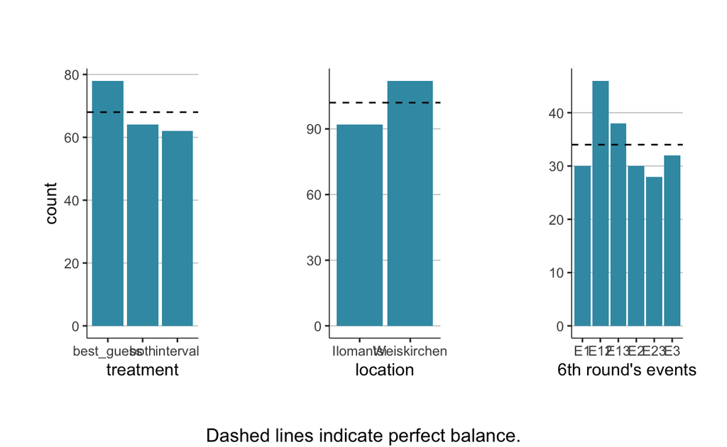

```r
col <- wes_palette("Zissou1")[1]
len <- NROW(data)

p1 <- ggplot(data,
             aes(x=Intro.1.player.treatment)) +
  geom_bar(fill = col) +
  geom_hline(yintercept = len/3, lty = 2) +
  layout +
  labs(x="treatment")

p2 <- ggplot(data,
             aes(x=Intro.1.player.location)) +
  geom_bar() +
  geom_bar(fill = col) +
  geom_hline(yintercept = len/2, lty = 2) +
  layout +
  labs(x="location",
       y="")

p3 <- ggplot(data,
             aes(x=Uncertainty.6.player.event_decision)) +
  geom_bar() +
  geom_bar(fill = col) +
  geom_hline(yintercept = len/6, lty = 2) +
  layout +
  labs(x="6th round's events",
       y="")

grid.arrange(
  p1,
  p2,
  p3,
  nrow = 1,
  top = "",
  bottom = "Dashed lines indicate perfect balance."
)
```

Baillon, Aurélien, Zhenxing Huang, Asli Selim, and Peter P. Wakker. 2018. “Measuring Ambiguity Attitudes for All (Natural) Events.” *Econometrica* 86 (5): 1839–58. https://doi.org/https://doi.org/10.3982/ECTA14370.

Chen, Daniel L., Martin Schonger, and Chris Wickens. 2016. “oTree-an Open-Source Platform for Laboratory, Online, and Field Experiments.” *Journal of Behavioral and Experimental Finance* 9: 88–97. https://doi.org/10.1016/j.jbef.2015.12.001.

[^1]: Eventually, we should rename these variables to make them shorter. Names such as `MP[round]` and `event[round]` would be great.
[^2]: Eventually, we should write either a function or a nested loop.